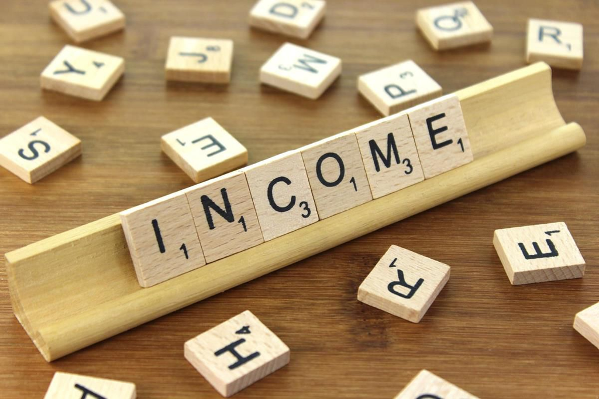

# USE CASE

#### DESCRIPTION

Identify the level of income qualification needed for the families in Latin America.

**Problem Statement Scenario:**  
Many social programs have a hard time ensuring that the right people are given enough aid. It’s tricky when a program focuses on the poorest segment of the population. This segment of the population can’t provide the necessary income and expense records to prove that they qualify.  
In Latin America, a popular method called Proxy Means Test (PMT) uses an algorithm to verify income qualification. With PMT, agencies use a model that considers a family’s observable household attributes like the material of their walls and ceiling or the assets found in their homes to classify them and predict their level of need.  
While this is an improvement, accuracy remains a problem as the region’s population grows and poverty declines. The Inter-American Development Bank (IDB)believes that new methods beyond traditional econometrics, based on a dataset of Costa Rican household characteristics, might help improve PMT’s performance.

**Task:**  
Following actions should be performed:  
1. Identify the output variable.  
2. Understand the type of data.  
3. Check if there are any biases in your dataset.  
4. Check whether all members of the house have the same poverty level.  
5. Check if there is a house without a family head.  
6. Set poverty level of the members and the head of the house within a family.  
7. Count how many null values are existing in columns.  
8. Remove null value rows of the target variable.  
9. Predict the accuracy using random forest classifier.  
10. Check the accuracy using random forest with cross validation.

## IMPORT LIBRARIES

```python
import numpy as np
import pandas as pd
import matplotlib.pyplot as plt
import seaborn as sns
from sklearn.feature_selection import SelectFromModel
from sklearn.ensemble import RandomForestClassifier
from sklearn.model_selection import train_test_split
from sklearn.model_selection import cross_val_score
from sklearn.model_selection import KFold
from sklearn.preprocessing import StandardScaler
from statsmodels.stats.outliers_influence import variance_inflation_factor
from sklearn.metrics import accuracy_score,confusion_matrix,f1_score,classification_report


%matplotlib inline

import warnings
warnings.filterwarnings('ignore')
```

## Data Analysis (EDA)

```python
data_train = pd.read_csv("C:/Users/VAIO/Downloads/SimpliLearn/Machine Learning/Assessments/Income Qualification/train.csv")
data_train.head()
```

|  | Id | v2a1 | hacdor | rooms | hacapo | v14a | refrig | v18q | v18q1 | r4h1 | ... | SQBescolari | SQBage | SQBhogar_total | SQBedjefe | SQBhogar_nin | SQBovercrowding | SQBdependency | SQBmeaned | agesq | Target |
| --- | --- | --- | --- | --- | --- | --- | --- | --- | --- | --- | --- | --- | --- | --- | --- | --- | --- | --- | --- | --- | --- |
| 0 | ID_279628684 | 190000.0 | 0 | 3 | 0 | 1 | 1 | 0 | NaN | 0 | ... | 100 | 1849 | 1 | 100 | 0 | 1.000000 | 0.0 | 100.0 | 1849 | 4 |
| 1 | ID_f29eb3ddd | 135000.0 | 0 | 4 | 0 | 1 | 1 | 1 | 1.0 | 0 | ... | 144 | 4489 | 1 | 144 | 0 | 1.000000 | 64.0 | 144.0 | 4489 | 4 |
| 2 | ID_68de51c94 | NaN | 0 | 8 | 0 | 1 | 1 | 0 | NaN | 0 | ... | 121 | 8464 | 1 | 0 | 0 | 0.250000 | 64.0 | 121.0 | 8464 | 4 |
| 3 | ID_d671db89c | 180000.0 | 0 | 5 | 0 | 1 | 1 | 1 | 1.0 | 0 | ... | 81 | 289 | 16 | 121 | 4 | 1.777778 | 1.0 | 121.0 | 289 | 4 |
| 4 | ID_d56d6f5f5 | 180000.0 | 0 | 5 | 0 | 1 | 1 | 1 | 1.0 | 0 | ... | 121 | 1369 | 16 | 121 | 4 | 1.777778 | 1.0 | 121.0 | 1369 | 4 |

5 rows × 143 columns

```python
data_test = pd.read_csv("C:/Users/VAIO/Downloads/SimpliLearn/Machine Learning/Assessments/Income Qualification/test.csv")
data_test.head()
```

|  | Id | v2a1 | hacdor | rooms | hacapo | v14a | refrig | v18q | v18q1 | r4h1 | ... | age | SQBescolari | SQBage | SQBhogar_total | SQBedjefe | SQBhogar_nin | SQBovercrowding | SQBdependency | SQBmeaned | agesq |
| --- | --- | --- | --- | --- | --- | --- | --- | --- | --- | --- | --- | --- | --- | --- | --- | --- | --- | --- | --- | --- | --- |
| 0 | ID_2f6873615 | NaN | 0 | 5 | 0 | 1 | 1 | 0 | NaN | 1 | ... | 4 | 0 | 16 | 9 | 0 | 1 | 2.25 | 0.25 | 272.25 | 16 |
| 1 | ID_1c78846d2 | NaN | 0 | 5 | 0 | 1 | 1 | 0 | NaN | 1 | ... | 41 | 256 | 1681 | 9 | 0 | 1 | 2.25 | 0.25 | 272.25 | 1681 |
| 2 | ID_e5442cf6a | NaN | 0 | 5 | 0 | 1 | 1 | 0 | NaN | 1 | ... | 41 | 289 | 1681 | 9 | 0 | 1 | 2.25 | 0.25 | 272.25 | 1681 |
| 3 | ID_a8db26a79 | NaN | 0 | 14 | 0 | 1 | 1 | 1 | 1.0 | 0 | ... | 59 | 256 | 3481 | 1 | 256 | 0 | 1.00 | 0.00 | 256.00 | 3481 |
| 4 | ID_a62966799 | 175000.0 | 0 | 4 | 0 | 1 | 1 | 1 | 1.0 | 0 | ... | 18 | 121 | 324 | 1 | 0 | 1 | 0.25 | 64.00 | NaN | 324 |

5 rows × 142 columns

```python
print("Total records present in train data: ", data_train.shape, "\n")
print("Total records present in test data: ", data_test.shape, "\n")
```

```
Total records present in train data:  (9557, 143)

Total records present in test data:  (23856, 142)
```

**TASK 1: Identify the Output Variable**

```python
for i in data_train.columns:
    if i in data_test.columns:
        continue
    else:
        print("The column not present in Test Data is: ", i)
```

```
The column not present in Test Data is:  Target
```

**Analysis:** Since **Target** is not present in the Test Data, Hence it is the **Output Variable**

```python
labels = ["Extereme", "Moderate", "Vulnerable", "NonVulnerable"]
povertyLevels = data_train['Target'].value_counts().to_frame().sort_index(ascending=True)
povertyLevels
```

|  | Target |
| --- | --- |
| 1 | 755 |
| 2 | 1597 |
| 3 | 1209 |
| 4 | 5996 |

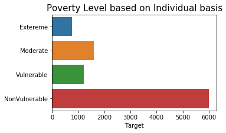

```python
plt.figure(figsize=(5,3))
ax = sns.barplot(y=labels,x=povertyLevels['Target'])
plt.tick_params(axis="x", labelsize = 10)
plt.title("Poverty Level based on Individual basis", fontdict = {'fontsize' : 15})
```

**TASK 2: Understand the type of data**

```python
data_train.info()
```

```
<class 'pandas.core.frame.DataFrame'>
RangeIndex: 9557 entries, 0 to 9556
Columns: 143 entries, Id to Target
dtypes: float64(8), int64(130), object(5)
memory usage: 10.4+ MB
```

**Train data has 3 different data type features:**  
**Float :** 8 Features  
**Int :** 130 features  
**Object:** 5 features

```python
numericfeatures = [col for col in data_train.columns if (data_train[col].dtype == 'float64')
                   | (data_train[col].dtype == 'int64') & (col != 'Target')]
```

```python
objectfeatures = [obj for obj in data_train.columns if data_train[obj].dtype == 'object']
objectfeatures
```

```
['Id', 'idhogar', 'dependency', 'edjefe', 'edjefa']
```

Created array containing the Object features: **objectfeatures** and Numeric features: **numericfeatures**(except output variable: **Target**)

```python
objectfeatures.remove("Id")
objectfeatures.remove("idhogar")
objectfeatures
```

```
['dependency', 'edjefe', 'edjefa']
```

```python
# Finding Unique Values for Object Features

for col in data_train[objectfeatures]:
    print("Unique values for: ", col)
    print(data_train[col].unique())
    print("\n")
```

```
Unique values for:  dependency
['no' '8' 'yes' '3' '.5' '.25' '2' '.66666669' '.33333334' '1.5'
 '.40000001' '.75' '1.25' '.2' '2.5' '1.2' '4' '1.3333334' '2.25'
 '.22222222' '5' '.83333331' '.80000001' '6' '3.5' '1.6666666' '.2857143'
 '1.75' '.71428573' '.16666667' '.60000002']


Unique values for:  edjefe
['10' '12' 'no' '11' '9' '15' '4' '6' '8' '17' '7' '16' '14' '5' '21' '2'
 '19' 'yes' '3' '18' '13' '20']


Unique values for:  edjefa
['no' '11' '4' '10' '9' '15' '7' '14' '13' '8' '17' '6' '5' '3' '16' '19'
 'yes' '21' '12' '2' '20' '18']
```

Create and apply function to YES and NO with 1 and 0 in **object features**

```python
def map(i):
    if i=='yes':
        return(float(1))
    elif i=='no':
        return(float(0))
    else:
        return(float(i))
```

```python
for column in objectfeatures:
    data_train[column] = data_train[column].apply(map)
```

Verify if **YES & NO** is replaced with **1 & 0**

```python
print("Unique values for edjefe: ", data_train['edjefe'].unique())
```

```
Unique values for edjefe:  [10. 12.  0. 11.  9. 15.  4.  6.  8. 17.  7. 16. 14.  5. 21.  2. 19.  1.
  3. 18. 13. 20.]
```

**TASK 4: Check whether all members of the house have the same poverty level.**

```python
# Groupby the household and figure out the number of unique values
all_equal = data_train.groupby('idhogar')['Target'].apply(lambda x: x.nunique() == 1)

# Households where targets are not all equal
not_equal = all_equal[all_equal != True]
print('There are {} households where the family members do not all have the same target.'.format(len(not_equal)))
```

```
There are 85 households where the family members do not all have the same target.
```

```python
data_train[data_train['idhogar'] == not_equal.index[0]][['idhogar', 'parentesco1', 'Target']]
```

|  | idhogar | parentesco1 | Target |
| --- | --- | --- | --- |
| 7651 | 0172ab1d9 | 0 | 3 |
| 7652 | 0172ab1d9 | 0 | 2 |
| 7653 | 0172ab1d9 | 0 | 3 |
| 7654 | 0172ab1d9 | 1 | 3 |
| 7655 | 0172ab1d9 | 0 | 2 |

**Analysis:** We can see that the member of same family has different **Target labels.**  
Since this cannot be true, hence we can say that few data are misrepresented. We will fix the Target Label, for misrepresented data's.

**TASK 6: Set poverty level of the members and the head of the house within a family.**

```python
# Iterate through each household
for household in not_equal.index:
    # Find correct label for head of household
    true_target = int(data_train[(data_train['idhogar'] == household) & (data_train['parentesco1'] == 1.0)]['Target'])

    # Set correct label for all members in the household
    data_train.loc[data_train['idhogar'] == household, 'Target'] = true_target


# Groupby the household and figure out the number of unique values
all_equal = data_train.groupby('idhogar')['Target'].apply(lambda x: x.nunique() == 1)

# Households where targets are not all equal
not_equal = all_equal[all_equal != True]
print('There are {} households where the family members do not have the same target.'.format(len(not_equal)))
```

```
There are 0 households where the family members do not have the same target.
```

```python
data_train.loc[data_train['idhogar'] == '0172ab1d9',['idhogar','Target']]
```

|  | idhogar | Target |
| --- | --- | --- |
| 7651 | 0172ab1d9 | 3 |
| 7652 | 0172ab1d9 | 3 |
| 7653 | 0172ab1d9 | 3 |
| 7654 | 0172ab1d9 | 3 |
| 7655 | 0172ab1d9 | 3 |

We haved fixed the Taget Labels for the household now

**TASK 5: Check if there is a house without a family head.**

Feature which tells us about the Family Head: **parentesco1**  
**parentesco1 = 1** (if household head)

```python
data_train['parentesco1'].value_counts()
```

```
0    6584
1    2973
Name: parentesco1, dtype: int64
```

Feature **idhogar** describes the unique id for **each household**. The unique count will give us information on how many households are present in the dataset.

```python
data_train['idhogar'].value_counts()
```

```
fd8a6d014    13
0c7436de6    12
ae6cf0558    12
4476ccd4c    11
6b35cdcf0    11
             ..
7c1cfa65c     1
188e498f3     1
223dab3ac     1
1bb8a3f9c     1
2e2acffa3     1
Name: idhogar, Length: 2988, dtype: int64
```

There are **2988** families/household discussed about in the data

```python
household_head = data_train.groupby('idhogar')['parentesco1'].sum()
household_head.value_counts()
```

```
1    2973
0      15
Name: parentesco1, dtype: int64
```

**Analysis:** There are 15 familes/househlds without a family **head**

```python
household_head_frame = household_head.value_counts().to_frame()
household_head_frame
```

|  | parentesco1 |
| --- | --- |
| 1 | 2973 |
| 0 | 15 |

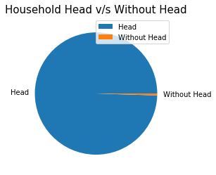

```python
labels = ["Head", "Without Head"]
plt.tick_params(axis="y", labelsize = 10)
plt.pie(household_head_frame, labels=labels)
plt.title("Household Head v/s Without Head", fontdict = {'fontsize' : 15})
plt.legend()
```

**TASK 3: Check if there are any biases in your dataset.**

```
1     222
2     442
3     355
4    1954
Name: Target, dtype: int64
```

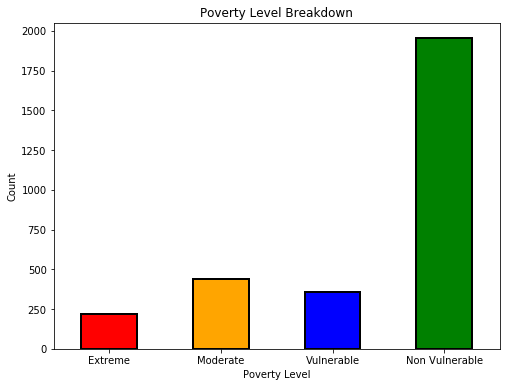

```python
targetLabels = data_train.loc[(data_train['Target'].notnull()) & (data_train['parentesco1'] == 1), ['Target', 'idhogar']]
label_counts = targetLabels['Target'].value_counts().sort_index()

# Bar plot of occurrences of each label
from collections import OrderedDict
colors = OrderedDict({1: 'red', 2: 'orange', 3: 'blue', 4: 'green'})
poverty_mapping = OrderedDict({1: 'Extreme', 2: 'Moderate', 3: 'Vulnerable', 4: 'Non Vulnerable'})
label_counts.plot.bar(figsize = (8, 6),
                      color = colors.values(),
                      edgecolor = 'k', linewidth = 2)

# labels and titles
plt.xlabel('Poverty Level'); plt.ylabel('Count');
plt.xticks([x - 1 for x in poverty_mapping.keys()],
           list(poverty_mapping.values()), rotation = 360)
plt.title('Poverty Level Breakdown');

label_counts
```

**Analysis:**We can see the data is **Unbalanced**. Hence we can confirm that there is **biasness** in the dataset

**TASK 7: Count how many null values are existing in columns.**

```python
data_train[objectfeatures].isnull().any()
```

```
dependency    False
edjefe        False
edjefa        False
dtype: bool
```

```python
nullvalues = data_train[numericfeatures].isnull().sum()
nullvalues[nullvalues > 0]
```

```
v2a1         6860
v18q1        7342
rez_esc      7928
meaneduc        5
SQBmeaned       5
dtype: int64
```

**v2a1:** Monthly Rent Payment  
**v18q1:** Number of tablets household owns  
**rez_esc:** Years behind in school

```python
data_train['Target'].isnull().any()
```

```
False
```

**TASK 8: Remove null value rows of the target variable.**

**Analysis:** There is no **null** value present in the **Target** variable

Remove **null** value present in the **v2a1**feature variable

**v2a1** is corelated with features like  
**tipovivi1** =1 own and fully paid house  
**tipovivi2** =1 own, paying in installments  
**tipovivi3** =1 rented  
**tipovivi4** =1 precarious  
**tipovivi5** =1 other(assigned, borrowed)

```python
nullRentValue = data_train[data_train['v2a1'].isnull()]
nullRentValue.head()
```

|  | Id | v2a1 | hacdor | rooms | hacapo | v14a | refrig | v18q | v18q1 | r4h1 | ... | SQBescolari | SQBage | SQBhogar_total | SQBedjefe | SQBhogar_nin | SQBovercrowding | SQBdependency | SQBmeaned | agesq | Target |
| --- | --- | --- | --- | --- | --- | --- | --- | --- | --- | --- | --- | --- | --- | --- | --- | --- | --- | --- | --- | --- | --- |
| 2 | ID_68de51c94 | NaN | 0 | 8 | 0 | 1 | 1 | 0 | NaN | 0 | ... | 121 | 8464 | 1 | 0 | 0 | 0.250000 | 64.0000 | 121.0000 | 8464 | 4 |
| 13 | ID_064b57869 | NaN | 0 | 4 | 0 | 1 | 1 | 1 | 1.0 | 0 | ... | 16 | 6241 | 4 | 0 | 0 | 1.000000 | 1.0000 | 90.2500 | 6241 | 4 |
| 14 | ID_5c837d8a4 | NaN | 0 | 4 | 0 | 1 | 1 | 1 | 1.0 | 0 | ... | 225 | 1521 | 4 | 0 | 0 | 1.000000 | 1.0000 | 90.2500 | 1521 | 4 |
| 26 | ID_e5cdba865 | NaN | 0 | 5 | 0 | 1 | 1 | 0 | NaN | 0 | ... | 225 | 1936 | 1 | 225 | 0 | 0.250000 | 0.0000 | 225.0000 | 1936 | 4 |
| 32 | ID_e24d9c3c9 | NaN | 0 | 5 | 0 | 1 | 1 | 0 | NaN | 0 | ... | 1 | 784 | 25 | 121 | 1 | 2.777778 | 0.0625 | 27.5625 | 784 | 4 |

5 rows × 143 columns

```python
rentDetailColumns = ['tipovivi1', 'tipovivi2', 'tipovivi3' , 'tipovivi4', 'tipovivi5']
nullRentValue[rentDetailColumns].head(3)
```

|  | tipovivi1 | tipovivi2 | tipovivi3 | tipovivi4 | tipovivi5 |
| --- | --- | --- | --- | --- | --- |
| 2 | 1 | 0 | 0 | 0 | 0 |
| 13 | 1 | 0 | 0 | 0 | 0 |
| 14 | 1 | 0 | 0 | 0 | 0 |

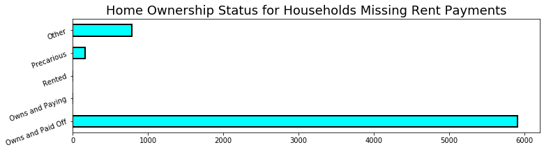

```python
rentDetails= [x for x in rentDetailColumns]

# Plot of the home ownership variables for home missing rent payments
data_train.loc[data_train['v2a1'].isnull(), rentDetails].sum().plot.barh(figsize = (12, 3),
                                                                        color = 'cyan',
                                                                  edgecolor = 'k', linewidth = 2);
plt.yticks([0, 1, 2, 3, 4],
           ['Owns and Paid Off', 'Owns and Paying', 'Rented', 'Precarious', 'Other'],
          rotation = 20)
plt.title('Home Ownership Status for Households Missing Rent Payments', size = 18);
```

**Analysis:** Looking at the above data it makes sense that when the house is fully paid, there will be no monthly rent payment.  
Imputing the missing values with **0**

```python
data_train['v2a1'].fillna(value=0, inplace=True)
data_train['v2a1'].isnull().sum()
```

```
0
```

Remove **null** value present in the **v18q1**feature variable

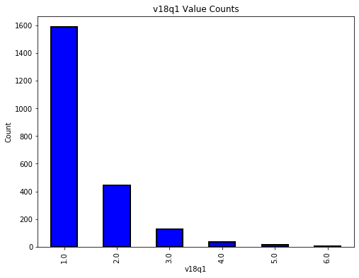

```python
plt.figure(figsize = (8, 6))
col='v18q1'
data_train[col].value_counts().sort_index().plot.bar(color = 'blue',
                                             edgecolor = 'k',
                                             linewidth = 2)
plt.xlabel(f'{col}'); plt.title(f'{col} Value Counts'); plt.ylabel('Count')
plt.show();
```

```python
nullTablets = data_train[data_train['v18q1'].isnull()]
nullTablets.head(3)
```

|  | Id | v2a1 | hacdor | rooms | hacapo | v14a | refrig | v18q | v18q1 | r4h1 | ... | SQBescolari | SQBage | SQBhogar_total | SQBedjefe | SQBhogar_nin | SQBovercrowding | SQBdependency | SQBmeaned | agesq | Target |
| --- | --- | --- | --- | --- | --- | --- | --- | --- | --- | --- | --- | --- | --- | --- | --- | --- | --- | --- | --- | --- | --- |
| 0 | ID_279628684 | 190000.0 | 0 | 3 | 0 | 1 | 1 | 0 | NaN | 0 | ... | 100 | 1849 | 1 | 100 | 0 | 1.00 | 0.0 | 100.0 | 1849 | 4 |
| 2 | ID_68de51c94 | 0.0 | 0 | 8 | 0 | 1 | 1 | 0 | NaN | 0 | ... | 121 | 8464 | 1 | 0 | 0 | 0.25 | 64.0 | 121.0 | 8464 | 4 |
| 7 | ID_3e04e571e | 130000.0 | 1 | 2 | 0 | 1 | 1 | 0 | NaN | 0 | ... | 0 | 49 | 16 | 81 | 4 | 16.00 | 1.0 | 100.0 | 49 | 4 |

3 rows × 143 columns

```python
nullTablesIndividual = nullTablets['v18q']
print("Check for Table count when there is > 1 tablet with individual: ", nullTablesIndividual[nullTablesIndividual > 0].count(), "\n")
print("Check for Table count when there is 0 tablet with individual: ", nullTablesIndividual[nullTablesIndividual == 0].count())
```

```
Check for Table count when there is > 1 tablet with individual:  0

Check for Table count when there is 0 tablet with individual:  7342
```

**Analysis:** v18q1 is **NAN** only when the value of **v18q** is **0**  
**Replacing the NAN values with 0**

```python
data_train['v18q1'].fillna(value=0, inplace=True)
data_train['v18q1'].isnull().sum()
```

```
0
```

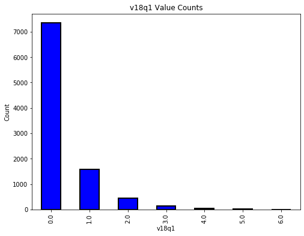

```python
plt.figure(figsize = (8, 6))
col='v18q1'
data_train[col].value_counts().sort_index().plot.bar(color = 'blue',
                                             edgecolor = 'k',
                                             linewidth = 2)
plt.xlabel(f'{col}'); plt.title(f'{col} Value Counts'); plt.ylabel('Count')
```

Remove **null** value present in the **meaneduc & SQBmeaned** feature variable

```python
nullMeanEduc = data_train[data_train['meaneduc'].isnull()]
nullMeanEduc.head()
```

|  | Id | v2a1 | hacdor | rooms | hacapo | v14a | refrig | v18q | v18q1 | r4h1 | ... | SQBescolari | SQBage | SQBhogar_total | SQBedjefe | SQBhogar_nin | SQBovercrowding | SQBdependency | SQBmeaned | agesq | Target |
| --- | --- | --- | --- | --- | --- | --- | --- | --- | --- | --- | --- | --- | --- | --- | --- | --- | --- | --- | --- | --- | --- |
| 1291 | ID_bd8e11b0f | 0.0 | 0 | 7 | 0 | 1 | 1 | 0 | 0.0 | 0 | ... | 100 | 324 | 1 | 0 | 1 | 0.04 | 64.0 | NaN | 324 | 4 |
| 1840 | ID_46ff87316 | 110000.0 | 0 | 1 | 0 | 1 | 1 | 0 | 0.0 | 0 | ... | 36 | 324 | 4 | 16 | 4 | 4.00 | 64.0 | NaN | 324 | 4 |
| 1841 | ID_69f50bf3e | 110000.0 | 0 | 1 | 0 | 1 | 1 | 0 | 0.0 | 0 | ... | 16 | 324 | 4 | 16 | 4 | 4.00 | 64.0 | NaN | 324 | 4 |
| 2049 | ID_db3168f9f | 180000.0 | 0 | 3 | 0 | 1 | 1 | 0 | 0.0 | 0 | ... | 144 | 361 | 4 | 144 | 4 | 1.00 | 64.0 | NaN | 361 | 4 |
| 2050 | ID_2a7615902 | 180000.0 | 0 | 3 | 0 | 1 | 1 | 0 | 0.0 | 0 | ... | 144 | 361 | 4 | 144 | 4 | 1.00 | 64.0 | NaN | 361 | 4 |

5 rows × 143 columns

```python
nullMeanEduc = nullMeanEduc.loc[:,['age','meaneduc','idhogar','instlevel1','hogar_adul']]
nullMeanEduc
```

|  | age | meaneduc | idhogar | instlevel1 | hogar_adul |
| --- | --- | --- | --- | --- | --- |
| 1291 | 18 | NaN | 1b31fd159 | 0 | 0 |
| 1840 | 18 | NaN | a874b7ce7 | 0 | 0 |
| 1841 | 18 | NaN | a874b7ce7 | 0 | 0 |
| 2049 | 19 | NaN | faaebf71a | 0 | 0 |
| 2050 | 19 | NaN | faaebf71a | 0 | 0 |

```python
data_train['meaneduc'].fillna(0,inplace=True)
data_train['SQBmeaned'].fillna(0,inplace=True)
print(data_train.isna().sum().value_counts())
```

```
0       142
7928      1
dtype: int64
```

Remove **null** value present in the **rez_esc** feature variable

```python
data_train.drop(columns=['rez_esc'], inplace=True)
```

```python
data_train.shape
```

```
(9557, 142)
```

**Find if there exists any feature with 0 variance**

```python
dataVariance = data_train.var()
toBeDroppedRows = dataVariance[dataVariance == 0]
toBeDroppedRows
```

```
elimbasu5    0.0
dtype: float64
```

**Check for Highly Correlated Data**

```python
correlation = data_train.corr()

# Select upper triangle of correlation matrix
upper = correlation.where(np.triu(np.ones(correlation.shape), k=1).astype(np.bool))

# Find index of feature columns with correlation greater than 0.95
highVarianceColumns = [column for column in upper.columns if any(abs(upper[column]) > 0.95)]

highVarianceColumns
```

```
['tamhog',
 'hhsize',
 'coopele',
 'female',
 'hogar_total',
 'area2',
 'SQBage',
 'SQBhogar_total',
 'agesq']
```

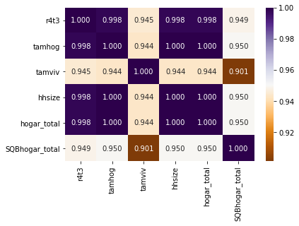

```python
sns.heatmap(correlation.loc[correlation['tamhog'].abs() > 0.9, correlation['tamhog'].abs() > 0.9],
            annot=True, cmap = plt.cm.PuOr, fmt='.3f');
```

Remove the features which has higer correlation

```python
data_train.drop(columns=highVarianceColumns,inplace=True)
data_train.shape
```

```
(9557, 133)
```

Remove Unwanted Features

```python
featuresToRemove = ['Id','elimbasu5','idhogar','tamviv','SQBescolari','SQBedjefe','SQBhogar_nin','SQBmeaned',
                    'SQBdependency','SQBovercrowding']

data_train.drop(columns=featuresToRemove,inplace=True)
data_train.shape
```

```
(9557, 123)
```

**Calculate VIF Scores for features left**

```python
vif = pd.DataFrame()

def calc_vif(X):

    # Calculating VIF
    vif["variables"] = X.columns
    vif["VIF"] = [variance_inflation_factor(X.values, i) for i in range(X.shape[1])]

    return(vif.head())

X = data_train.iloc[:,:-1]
calc_vif(X)
```

|  | variables | VIF |
| --- | --- | --- |
| 0 | v2a1 | 2.314023 |
| 1 | hacdor | 2.848814 |
| 2 | rooms | 3.661095 |
| 3 | hacapo | 2.069508 |
| 4 | v14a | 1.661559 |

```python
vifFeatures = vif[vif['VIF'] < 5.0]
vifFeatures
```

|  | variables | VIF |
| --- | --- | --- |
| 0 | v2a1 | 2.314023 |
| 1 | hacdor | 2.848814 |
| 2 | rooms | 3.661095 |
| 3 | hacapo | 2.069508 |
| 4 | v14a | 1.661559 |
| 5 | refrig | 1.238010 |
| 6 | v18q | 3.822567 |
| 7 | v18q1 | 3.847648 |
| 34 | techocane | 3.517894 |
| 35 | techootro | 2.835830 |
| 36 | cielorazo | 1.911436 |
| 40 | public | 1.556971 |
| 41 | planpri | 1.014696 |
| 42 | noelec | 1.196070 |
| 66 | dis | 1.133267 |
| 67 | male | 1.537065 |
| 89 | hogar_mayor | 2.833492 |
| 90 | dependency | 2.413497 |
| 91 | edjefe | 4.790400 |
| 92 | edjefa | 4.076021 |
| 93 | meaneduc | 3.421691 |
| 110 | computer | 1.251761 |
| 111 | television | 1.155111 |
| 112 | mobilephone | 1.276683 |
| 113 | qmobilephone | 2.619380 |
| 120 | area1 | 1.581404 |

## Feature Engineering

**Separating Feature and Label columns**

```python
featureNames = data_train.columns.to_list()
featureNames.remove('Target')
print("No of features taken into consideration: ", len(featureNames))
```

```
No of features taken into consideration:  122
```

```python
features = data_train.iloc[:,:-1]
label = data_train.loc[:,['Target']]

print("Features shape: ",features.shape)
print("Label shape: ",label.shape)
```

```
Features shape:  (9557, 122)
Label shape:  (9557, 1)
```

```python
features = features.values
label = label.values
```

**Finding Important Features using Select By Model**

```python
modelRFC = RandomForestClassifier()
selectFeaturesFromSFM = SelectFromModel(modelRFC)
selectFeaturesFromSFM.fit(features,label)
print(selectFeaturesFromSFM.get_support())
```

```
[ True False  True False False False  True  True  True  True  True  True
  True  True  True  True  True  True  True False  True False False False
 False False  True  True False False False False False False False False
  True False False False False False False False False False False False
 False  True  True False False False False False False False  True  True
 False  True  True False  True  True False False False False False False
 False False False False False False False False False False False False
 False False False  True  True  True  True  True  True  True False False
 False False False False False False False  True  True  True False False
 False False False  True False  True  True False False False False False
  True  True]
```

```python
selectedFeatures = []
model = RandomForestClassifier()
selectFeaturesFromSFM = SelectFromModel(model)
selectFeaturesFromSFM.fit(features,label)
for feature_list_index in selectFeaturesFromSFM.get_support(indices=True):
    selectedFeatures.append(featureNames[feature_list_index])

print(selectedFeatures,"\n")
print("Total features selected from SFM is: ", len(selectedFeatures))
```

[output not shown]

## Building initial model

**Applying Output of Feature Engineering**

```python
finalFeatures = selectFeaturesFromSFM.transform(features)
selectedFeaturesFrame= pd.DataFrame(finalFeatures, columns=selectedFeatures)
print("Shape of selected feature is: ", selectedFeaturesFrame.shape)
selectedFeaturesFrame.head()
```

```
Shape of selected feature is:  (9557, 39)
```

|  | v2a1 | rooms | v18q1 | r4h1 | r4h2 | r4h3 | r4m1 | r4m2 | r4m3 | r4t1 | ... | edjefa | meaneduc | bedrooms | overcrowding | tipovivi1 | television | qmobilephone | lugar1 | area1 | age |
| --- | --- | --- | --- | --- | --- | --- | --- | --- | --- | --- | --- | --- | --- | --- | --- | --- | --- | --- | --- | --- | --- |
| 0 | 190000.0 | 3.0 | 0.0 | 0.0 | 1.0 | 1.0 | 0.0 | 0.0 | 0.0 | 0.0 | ... | 0.0 | 10.0 | 1.0 | 1.000000 | 0.0 | 0.0 | 1.0 | 1.0 | 1.0 | 43.0 |
| 1 | 135000.0 | 4.0 | 1.0 | 0.0 | 1.0 | 1.0 | 0.0 | 0.0 | 0.0 | 0.0 | ... | 0.0 | 12.0 | 1.0 | 1.000000 | 0.0 | 0.0 | 1.0 | 1.0 | 1.0 | 67.0 |
| 2 | 0.0 | 8.0 | 0.0 | 0.0 | 0.0 | 0.0 | 0.0 | 1.0 | 1.0 | 0.0 | ... | 11.0 | 11.0 | 2.0 | 0.500000 | 1.0 | 0.0 | 0.0 | 1.0 | 1.0 | 92.0 |
| 3 | 180000.0 | 5.0 | 1.0 | 0.0 | 2.0 | 2.0 | 1.0 | 1.0 | 2.0 | 1.0 | ... | 0.0 | 11.0 | 3.0 | 1.333333 | 0.0 | 0.0 | 3.0 | 1.0 | 1.0 | 17.0 |
| 4 | 180000.0 | 5.0 | 1.0 | 0.0 | 2.0 | 2.0 | 1.0 | 1.0 | 2.0 | 1.0 | ... | 0.0 | 11.0 | 3.0 | 1.333333 | 0.0 | 0.0 | 3.0 | 1.0 | 1.0 | 37.0 |

5 rows × 39 columns

**TASK 9: Predict the accuracy using random forest classifier.**

```python
for i in range(1,10):
    X_train,X_test,y_train,y_test = train_test_split(finalFeatures, label, test_size=0.2, random_state = i)
    model1 = RandomForestClassifier()
    model1.fit(X_train,y_train)

    train_score = model1.score(X_train,y_train)
    test_score = model1.score(X_test,y_test)

    if (test_score > 0.95):
        print("Test: {} , Train: {} , RS : {}".format(test_score,train_score,i))
```

```
Test: 0.9665271966527197 , Train: 1.0 , RS : 1
Test: 0.9555439330543933 , Train: 1.0 , RS : 2
Test: 0.9612970711297071 , Train: 1.0 , RS : 3
Test: 0.9748953974895398 , Train: 1.0 , RS : 4
Test: 0.9607740585774058 , Train: 1.0 , RS : 5
Test: 0.9691422594142259 , Train: 1.0 , RS : 6
Test: 0.9602510460251046 , Train: 1.0 , RS : 7
Test: 0.9701882845188284 , Train: 1.0 , RS : 8
Test: 0.9576359832635983 , Train: 1.0 , RS : 9
```

**Analysis:** Maxinum Accuracy is obtained when **RS is 4**

## Train Test Data Split

```python
X_train,X_test,y_train,y_test = train_test_split(finalFeatures, label, test_size=0.2, random_state = 4)
X_train.shape, X_test.shape, y_train.shape, y_test.shape
```

```
((7645, 39), (1912, 39), (7645, 1), (1912, 1))
```

## Standard Scalar

```python
sc = StandardScaler()
X_train = sc.fit_transform(X_train)
X_test = sc.transform(X_test)
```

## Cross Validation

**Using Cross Validation technique to find the best accuracy result**

```python
crossValAlgo = RandomForestClassifier()
scores = cross_val_score(crossValAlgo,
                        finalFeatures,
                        label,
                        cv = 10) #5 or 10

scores
```

```
array([0.65167364, 0.67573222, 0.68200837, 0.64539749, 0.68096234,
       0.69142259, 0.60460251, 0.66282723, 0.60314136, 0.59790576])
```

**TASK 10: Check the accuracy using random forest with cross validation.**

**Applying K-fold Validation to check the best train-test split**

```python
kfoldModel = RandomForestClassifier()

from sklearn.model_selection import KFold

kfold = KFold(n_splits=10, #Use the same CV values that was applied in cross_val_score
             shuffle=True,
             random_state = 8) # To ensure the data is not randomized at every iteration

counter = 0

for train,test in kfold.split(finalFeatures):

    #Counter will help you track the sample split
    counter += 1

    #Extract the training set and testing set
    X_train,X_test = finalFeatures[train],finalFeatures[test]
    y_train,y_test = label[train] , label[test]

    #Fit the model
    kfoldModel.fit(X_train,y_train)

    if kfoldModel.score(X_test,y_test) > 0.96:
        print("Test Score {} Train Score {} for Sample Split {}".format(kfoldModel.score(X_test,y_test),kfoldModel.score(X_train,y_train),counter))
```

```
Test Score 0.9864016736401674 Train Score 1.0 for Sample Split 1
Test Score 0.9665271966527197 Train Score 1.0 for Sample Split 2
Test Score 0.9717573221757322 Train Score 1.0 for Sample Split 3
Test Score 0.9623430962343096 Train Score 1.0 for Sample Split 4
Test Score 0.9696652719665272 Train Score 1.0 for Sample Split 5
Test Score 0.9780334728033473 Train Score 1.0 for Sample Split 6
Test Score 0.9633891213389121 Train Score 1.0 for Sample Split 7
Test Score 0.9675392670157068 Train Score 1.0 for Sample Split 8
Test Score 0.9664921465968587 Train Score 1.0 for Sample Split 9
Test Score 0.9602094240837696 Train Score 1.0 for Sample Split 10
```

### Find the Parameters of Random Forest Classifier for Hyper parameter tuning

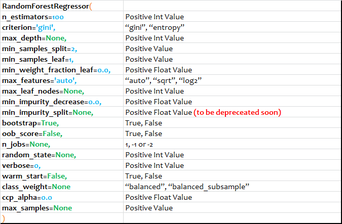

```python
#Step1: Design the parameter grid
criterionParameter = ['gini', 'entropy']
maxFeaturesParameter = ['auto', 'sqrt', 'log2']
nJobsParameter = [-2,-1,1]

paramGrid = dict(criterion=criterionParameter,
                max_features=maxFeaturesParameter,
                n_jobs=nJobsParameter)

# Step2: Initialize the algo
modelGridSearch = RandomForestClassifier()

#Step3: Search the best parameter for the data
from sklearn.model_selection import GridSearchCV
grid = GridSearchCV(modelGridSearch,
                   param_grid=paramGrid,
                   cv = 10) #Same as cross_val_score
```

```python
# Step4: Extract Results
grid.fit(finalFeatures,label)
```

```
GridSearchCV(cv=10, error_score=nan,
             estimator=RandomForestClassifier(bootstrap=True, ccp_alpha=0.0,
                                              class_weight=None,
                                              criterion='gini', max_depth=None,
                                              max_features='auto',
                                              max_leaf_nodes=None,
                                              max_samples=None,
                                              min_impurity_decrease=0.0,
                                              min_impurity_split=None,
                                              min_samples_leaf=1,
                                              min_samples_split=2,
                                              min_weight_fraction_leaf=0.0,
                                              n_estimators=100, n_jobs=None,
                                              oob_score=False,
                                              random_state=None, verbose=0,
                                              warm_start=False),
             iid='deprecated', n_jobs=None,
             param_grid={'criterion': ['gini', 'entropy'],
                         'max_features': ['auto', 'sqrt', 'log2'],
                         'n_jobs': [-2, -1, 1]},
             pre_dispatch='2*n_jobs', refit=True, return_train_score=False,
             scoring=None, verbose=0)
```

```python
grid.best_score_
```

```
0.6528125479199982
```

```python
grid.best_estimator_
```

```
RandomForestClassifier(bootstrap=True, ccp_alpha=0.0, class_weight=None,
                       criterion='gini', max_depth=None, max_features='auto',
                       max_leaf_nodes=None, max_samples=None,
                       min_impurity_decrease=0.0, min_impurity_split=None,
                       min_samples_leaf=1, min_samples_split=2,
                       min_weight_fraction_leaf=0.0, n_estimators=100,
                       n_jobs=-2, oob_score=False, random_state=None, verbose=0,
                       warm_start=False)
```

## Building Final Model

```python
kfold = KFold(n_splits=10, #Use the same CV values that was applied in cross_val_score
             shuffle=True,
             random_state = 8) # To ensure the data is not randomized at every iteration
counter = 0
for train,test in kfold.split(finalFeatures):

    #Counter will help you track the sample split
    counter += 1

    if counter == 1:
        X_train,X_test,y_train,y_test = finalFeatures[train],finalFeatures[test],label[train] ,label[test]
```

```python
finalModel = RandomForestClassifier()
finalModel.fit(X_train,y_train)
finalModel.score(X_test,y_test)
```

```
0.9822175732217573
```

```python
predictedValue = finalModel.predict(X_test)
```

```python
print(confusion_matrix(y_test,predictedValue))
```

```
[[ 71   0   0   3]
 [  1 159   0   4]
 [  1   0 121   5]
 [  0   1   2 588]]
```

```python
print(classification_report(y_test,predictedValue))
```

```
              precision    recall  f1-score   support

           1       0.97      0.96      0.97        74
           2       0.99      0.97      0.98       164
           3       0.98      0.95      0.97       127
           4       0.98      0.99      0.99       591

    accuracy                           0.98       956
   macro avg       0.98      0.97      0.98       956
weighted avg       0.98      0.98      0.98       956
```

**Visualizing the Target and Predicted Values**

```python
# Converting Dimensions of y_test from 2 to 1 dimension
y_test = y_test.ravel()
```

```python
predictedFrame = pd.DataFrame(predictedValue, columns=['Predicted'])
targetFrame = pd.DataFrame(y_test, columns=['Target'])
Observed_Predicted_Table =pd.concat([targetFrame.reset_index(drop=True),predictedFrame],axis=1)
Observed_Predicted_Table.head()
```

|  | Target | Predicted |
| --- | --- | --- |
| 0 | 4 | 4 |
| 1 | 4 | 4 |
| 2 | 4 | 4 |
| 3 | 4 | 4 |
| 4 | 4 | 4 |

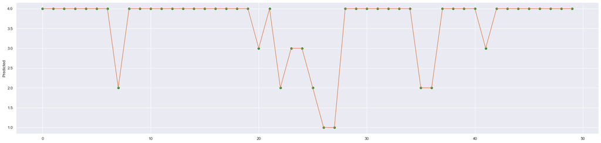

```python
Observed_Predicted_Table_Split = Observed_Predicted_Table.head(50)
fig, ax = plt.subplots()
sns.set(color_codes=True)
sns.set(rc={'figure.figsize':(30, 7)})
sns.regplot(Observed_Predicted_Table_Split.index, Observed_Predicted_Table_Split.Target, fit_reg=False, ax=ax,scatter_kws={"color": "green"});
sns.lineplot(Observed_Predicted_Table_Split.index, Observed_Predicted_Table_Split.Predicted)
```

### Deploy the final model

```python
import pickle
pickle.dump(finalModel , open('modelIncomeQualification.model' , 'wb') )
```